# Introduction to Health Data Science (PU5058/PU5063): Assessment 2

Student ID: 52642998

25 November 2026

```r
library(ggplot2)
library(knitr)
library(patchwork)
```

# Research question

> Among adults aged 60 to 75 in primary care diagnosed with COPD, does **smoking status** have any association with how far they are able walk within 6 minutes measured at baseline and six times more over 6 months, taking into account their usual **level of physical activity**?

It would be beneficial to understand whether there is a pattern in how far the participants are able to walk within 6 minutes during each follow up depending on their smoking status and whether their usual **level of physical activity** also affects the distance they are able to walk. If there is, then a further analysis into how much it affects and whether a baseline for each permutation exists by checking the relevant statistics, followed up with knowing if a progression or even regression exists at each follow-up. It is worth knowing the relationships between these exposures as it could serve as a promoting point for avoiding smoking as well as having a better physical activity level despite having COPD.

# Data import and structure

```r
# Baseline data
baseline = read.table('data/Baseline_Data.tsv', header = TRUE, sep = '\t')
str(baseline)
```

```
## 'data.frame':    501 obs. of  10 variables:
##  $ ID           : chr  "COPD000001" "COPD000002" "COPD000003" "COPD000004" ...
##  $ age          : int  67 67 61 65 68 63 72 68 62 66 ...
##  $ sex          : int  1 2 1 2 2 2 2 2 2 2 ...
##  $ smoker       : int  1 1 1 1 1 1 1 1 1 2 ...
##  $ bmi          : num  17.9 25.4 24.3 20.5 27.3 32.8 31.9 27.6 28.3 27.1 ...
##  $ phy_activity : chr  "Very_high" "Low" "Low" "Very_high" ...
##  $ diabetes     : int  0 0 0 0 0 0 0 0 0 0 ...
##  $ ethnicity    : int  1 3 1 1 1 3 2 1 1 2 ...
##  $ inhaler      : int  1 1 1 0 1 0 1 1 0 1 ...
##  $ exacerbations: int  0 3 1 0 1 1 2 0 2 1 ...
```

```r
summary(baseline)
```

```
##          ID           age             sex             smoker
##  Length   :501   Min.   :60.00   Min.   : 1.000   Min.   :-999.000
##  N.unique :500   1st Qu.:64.00   1st Qu.: 1.000   1st Qu.:   1.000
##  N.blank  :  0   Median :67.00   Median : 2.000   Median :   1.000
##  Min.nchar: 10   Mean   :67.57   Mean   : 1.557   Mean   :  -4.894
##  Max.nchar: 10   3rd Qu.:72.00   3rd Qu.: 2.000   3rd Qu.:   1.000
##                  Max.   :75.00   Max.   :12.000   Max.   :   2.000
##
##       bmi            phy_activity    diabetes        ethnicity
##  Min.   : 17.20   Length   :501   Min.   :0.0000   Min.   :1.000
##  1st Qu.: 25.00   N.unique :  5   1st Qu.:0.0000   1st Qu.:1.000
##  Median : 27.30   N.blank  :  0   Median :0.0000   Median :1.000
##  Mean   : 28.46   Min.nchar:  3   Mean   :0.1487   Mean   :1.409
##  3rd Qu.: 30.18   Max.nchar:  9   3rd Qu.:0.0000   3rd Qu.:2.000
##  Max.   :295.00   NAs      : 14   Max.   :1.0000   Max.   :4.000
##  NAs    :7                        NAs    :10       NAs    :12
##     inhaler       exacerbations
##  Min.   :0.0000   Min.   :0.0000
##  1st Qu.:1.0000   1st Qu.:0.0000
##  Median :1.0000   Median :0.0000
##  Mean   :0.7764   Mean   :0.7625
##  3rd Qu.:1.0000   3rd Qu.:1.0000
##  Max.   :1.0000   Max.   :6.0000
##
```

```r
# Visits data
visits = read.table('data/Visits_Data.tsv', header = TRUE, sep = '\t')
str(visits)
```

```
## 'data.frame':    3466 obs. of  3 variables:
##  $ ID      : chr  "COPD000001" "COPD000001" "COPD000001" "COPD000001" ...
##  $ visit   : int  0 1 2 3 4 5 6 0 1 2 ...
##  $ walk6min: num  498 499 518 509 513 ...
```

```r
summary(visits)
```

```
##          ID           visit          walk6min
##  Length   :3466   Min.   :0.000   Min.   :203.9
##  N.unique : 498   1st Qu.:1.000   1st Qu.:340.5
##  N.blank  :   0   Median :3.000   Median :376.4
##  Min.nchar:  10   Mean   :3.001   Mean   :379.3
##  Max.nchar:  10   3rd Qu.:5.000   3rd Qu.:418.2
##                   Max.   :6.000   Max.   :581.0
##                                   NAs    :197
```

```r
visits_per_id = aggregate(visit ~ ID, data = visits, FUN = length)
unique(visits_per_id$visit)
```

```
## [1] 7 6
```

```r
nrow(visits_per_id[visits_per_id$visit == 7, ])
```

```
## [1] 478
```

```r
nrow(visits_per_id[visits_per_id$visit == 6, ])
```

```
## [1] 20
```

The baseline data contains 501 rows of data with 10 columns (variables). Some of the data types from the baseline data are not automatically the correct data type according to the dictionary and also contain some NA values. Possible duplicate ID shown from the baseline summary with 501 observations but only 500 unique values. The visits data contains 3466 rows of data with 3 columns (variables), each participants are expected to have 7 visits total but 20 participants only have 6 visits while 478 participants have the full 7 visits.

# Data quality assessment and cleaning

## Baseline data

```r
# Duplicates
baseline[duplicated(baseline$ID), 'ID']
```

```
## [1] "COPD000078"
```

```r
baseline[baseline$ID == 'COPD000078', ] # Exact same row, index 78 and 501
```

```
##             ID age sex smoker bmi phy_activity diabetes ethnicity inhaler
## 78  COPD000078  62   1      1  30         Hihg        0         1       1
## 501 COPD000078  62   1      1  30         Hihg        0         1       1
##     exacerbations
## 78              1
## 501             1
```

```r
# Factor columns: sex, smoker, phy_activity, diabetes, ethnicity, inhaler
# Sex
unique(baseline$sex)
```

```
## [1]  1  2 12
```

```r
baseline[baseline$sex == 12, ] # 1 row
```

```
##             ID age sex smoker bmi phy_activity diabetes ethnicity inhaler
## 439 COPD000439  75  12      1  28          Low        0         3       0
##     exacerbations
## 439             0
```

```r
# Smoker
unique(baseline$smoker)
```

```
## [1]    1    2    0 -999
```

```r
baseline[baseline$smoker == -999, ] # 3 rows
```

```
##             ID age sex smoker  bmi phy_activity diabetes ethnicity inhaler
## 390 COPD000390  63   1   -999 23.2         High        0         2       0
## 416 COPD000416  63   1   -999 30.2         High        0         1       1
## 443 COPD000443  63   1   -999 27.3     Moderate        0         1       1
##     exacerbations
## 390             0
## 416             2
## 443             4
```

```r
# phy_activity
unique(baseline$phy_activity)
```

```
## [1] "Very_high" "Low"       "High"      "Moderate"  NA          "Hihg"
```

```r
baseline[baseline$phy_activity == 'Hihg' &
    !is.na(baseline$phy_activity), ] # 6 rows; Typo 'Hihg'
```

```
##             ID age sex smoker  bmi phy_activity diabetes ethnicity inhaler
## 78  COPD000078  62   1      1 30.0         Hihg        0         1       1
## 262 COPD000262  64   1      1 25.1         Hihg        0         3       1
## 350 COPD000350  63   2      1 25.0         Hihg        0         2       1
## 362 COPD000362  63   2      1 30.5         Hihg        0         1       1
## 365 COPD000365  72   1      1 27.0         Hihg        1         1       1
## 501 COPD000078  62   1      1 30.0         Hihg        0         1       1
##     exacerbations
## 78              1
## 262             1
## 350             3
## 362             0
## 365             1
## 501             1
```

```r
# Diabetes
unique(baseline$diabetes) # No issues
```

```
## [1]  0  1 NA
```

```r
# Ethnicity
unique(baseline$ethnicity)
```

```
## [1]  1  3  2 NA  4
```

```r
baseline[baseline$ethnicity == 4 &
    !is.na(baseline$ethnicity), -1] # 4 rows; Unclear error
```

```
##     age sex smoker  bmi phy_activity diabetes ethnicity inhaler exacerbations
## 40   60   2      2 35.2         High        0         4       1             0
## 120  73   1      1 34.2     Moderate        0         4       0             1
## 139  73   2      1 26.7         High        0         4       0             0
## 457  70   1      1 29.6    Very_high        0         4       1             1
```

```r
# Inhaler
unique(baseline$inhaler) # No issues
```

```
## [1] 1 0
```

```r
# Numerical / continuous columns: age, bmi
numerical_baseline_cols = c('age', 'bmi')
summary(baseline[, numerical_baseline_cols])
```

```
##       age             bmi
##  Min.   :60.00   Min.   : 17.20
##  1st Qu.:64.00   1st Qu.: 25.00
##  Median :67.00   Median : 27.30
##  Mean   :67.57   Mean   : 28.46
##  3rd Qu.:72.00   3rd Qu.: 30.18
##  Max.   :75.00   Max.   :295.00
##                  NAs    :7
```

```r
# BMI
head(baseline[order(baseline$bmi, decreasing = TRUE),
    c('ID', 'bmi')]) # Irregular BMI values of 288.0, 295.0
```

```
##             ID   bmi
## 237 COPD000237 295.0
## 14  COPD000014 288.0
## 401 COPD000401  38.4
## 250 COPD000250  38.1
## 149 COPD000149  36.7
## 86  COPD000086  36.5
```

```r
# Exacerbations
unique(baseline$exacerbations) # No issues
```

```
## [1] 0 3 1 2 4 6 5
```

```r
# Handling data issues
baseline = baseline[-501, ] # Duplicate
baseline$sex[baseline$sex == 12] = NA  # Sex
baseline$smoker[baseline$smoker == -999] = NA # Smoker
baseline$phy_activity[baseline$phy_activity == 'Hihg'] = 'High' # Physical activity
baseline$ethnicity[baseline$ethnicity == 4] = NA  # Ethnicity
baseline$bmi[baseline$bmi == 288 | baseline$bmi == 295] = NA # BMI

# Factor type of each categorical variables as new variables
baseline$fsex = factor(baseline$sex, levels = c(1, 2),
    labels = c('Female', 'Male')
)
baseline$fsmoker = factor(baseline$smoker, levels = c(0, 1, 2),
    labels = c('Never smoked', 'Ex smoker', 'Current smoker')
)
baseline$fphy_activity = factor(baseline$phy_activity,
    labels = c('Low', 'Moderate', 'High', 'Very_high')
)
baseline$fdiabetes = factor(baseline$diabetes, levels = c(0, 1),
    labels = c('No', 'Yes')
)
baseline$fethnicity = factor(baseline$ethnicity, levels = c(1, 2, 3),
    labels = c('Group1', 'Group2', 'Group3')
)
baseline$finhaler = factor(baseline$inhaler, levels = c(0, 1),
    labels = c('Not receiving inhaler', 'Receiving inhaler')
)
```

## Visits data

```r
str(visits)
```

```
## 'data.frame':    3466 obs. of  3 variables:
##  $ ID      : chr  "COPD000001" "COPD000001" "COPD000001" "COPD000001" ...
##  $ visit   : int  0 1 2 3 4 5 6 0 1 2 ...
##  $ walk6min: num  498 499 518 509 513 ...
```

```r
visits[duplicated(visits), ] # No full duplicates
```

```
## [1] ID       visit    walk6min
## <0 rows> (or 0-length row.names)
```

```r
visits[duplicated(visits[, c('ID', 'visit')]),
    c('ID', 'visit')] # No duplicates by ID and visit
```

```
## [1] ID    visit
## <0 rows> (or 0-length row.names)
```

```r
visits$fvisit = factor(visits$visit, levels = c(0, 1, 2, 3, 4, 5, 6),
    labels = c('Baseline', '1', '2', '3', '4', '5', '6')
)
```

## Data cleaning log

| No. | Dataset and variable | Problem found | Evidence | Kind of problem | Decision | Justification | Values or rows affected |
| --- | --- | --- | --- | --- | --- | --- | --- |
| 1 | baseline, all variables | Fully duplicated row | `baseline[duplicated(baseline$ID), 'ID']` shows the duplicated ID | Clear error | Remove row 501 | Duplicate ID found with all the other columns having the same data | 1, participant `COPD000078` |
| 2 | baseline, sex | Value of `12` found | `unique(baseline$sex)` shows the unique values of sex | Uncertain value | Update values to `NA` | It is not clear which label it’s originally meant to be | 1, participant `COPD000439` |
| 3 | baseline, smoker | Value of `-999` found | `unique(baseline$smoker)` shows the unique values of smoker | Clear error | Update values to `NA` | By convention the value `-999` is typically used to denote missing data | 3 rows |
| 4 | baseline, phy_activity | Label `Hihg` found | `unique(baseline$phy_activity)` shows the unique values of phy_activity | Uncertain value | Update label to `High` | The typo is obvious where instead of `High`, the label `Hihg` was given | 6 rows |
| 5 | baseline, ethnicity | Value of `4` found | `unique(baseline$ethnicity)` shows the unique values of ethnicity | Uncertain value | Update values to `NA` | It is not clear which label it’s originally meant to be | 4 rows |
| 6 | baseline, bmi | Irregular extreme values | `summary(baseline$bmi)` shows the max value of 295 and ordering the data based on bmi in a descending order shows another improbable bmi value of 288 | Uncertain value | Update values to `NA` | The likeliest value is 29.5 and 28.8 but no way to confirm | 2 rows |
| 7 | baseline; sex, smoker, phy_activity, diabetes, ethnicity, inhaler | Wrong data type | `str(baseline)` shows the data type | Wrong data type | Cast to factor as a new corresponding variable prefixed with `f` | The data type is casted to factor following the data dictionary | All rows |

# Missing data

## Baseline data

Missing data in the baseline data occured in the variables: **smoking status, usual level of physical activity, diabetes status, and ethnicity** with not very clear patterns on the missingness

| Variable | Total missing | Pattern | Type of missing |
| --- | --- | --- | --- |
| Smoking status | 3 rows | Too little data to find any missing patterns | Missing completely at random |
| Usual level of physical activity | 14 rows | Majority of the missing occurred are participants ex smokers, but not enough data to conclude a confident pattern | Missing completely at random |
| Diabetes | 10 rows | Majority of the missing occurred are participants receiving inhaler, but not enough data to conclude a confident pattern | Missing completely at random |
| Ethnicity | 16 rows | Majority of the missing occurred are participants without diabetes, but not enough data to conclude a confident pattern | Missing completely at random |

All the variables with missing data are presumed to be missing completely at random because while the majority of the missing data occurred on patients receiving inhaler, there is not enough data to draw a clear pattern.

## Visits data

```r
colSums(is.na(visits))
```

```
##       ID    visit walk6min   fvisit
##        0        0      197        0
```

```r
kable(table(visits[is.na(visits$walk6min), 'visit']), col.names = c('Visit', 'Total NA'), align = 'l')
```

| Visit | Total NA |
| --- | --- |
| 0 | 24 |
| 1 | 25 |
| 2 | 24 |
| 3 | 22 |
| 4 | 24 |
| 5 | 43 |
| 6 | 35 |

```r
invalid_participants = visits[which(visits$visit == 0 & is.na(visits$walk6min)), 'ID']

nrow(visits[visits$ID %in% invalid_participants, ]) # Total rows with missing baseline measures
```

```
## [1] 168
```

```r
# Exclude all participants with no baseline measure
valid_visits = visits[!visits$ID %in% invalid_participants, ]
nrow(valid_visits) # 3298 rows left in the visits data
```

```
## [1] 3298
```

# Data linkage

Since baseline data has 500 rows of data and visits had 3298 rows of data post data cleaning, after merging there should be 3298 rows of data assuming both datasets contains the same unique participant IDs.

```r
linked_data = merge(baseline, valid_visits, by = 'ID',
    all.x = FALSE, all.y = FALSE
)
nrow(linked_data)
```

```
## [1] 3298
```

The total dataset after merging is 3298 rows. **Inner join** is used here because only participants that had their demographic characteristics and exposures taken as well as their outcome measures are needed for the analysis. Participants that had their demographic characteristics and exposures measured but do not have any baseline or outcome measures (or vice versa, patients that have a baseline or outcome measures but don’t exist in the demographic characteristics and exposures dataset) are excluded and treated as invalid participants. The merged dataset now contains the participant information, characteristics such as pre-existing conditions or exposures, as well as their baseline measure and all their follow-ups.

# Exploratory analysis and visualisation

## Exposure analysis

```r
total_smokers = as.data.frame(table(baseline$fsmoker))
total_smokers$total_pct = round(total_smokers$Freq / sum(total_smokers$Freq) * 100, 1)
kable(total_smokers, align = 'l',
    col.names = c('Smoking status', 'Total participants (n)', 'Total participants (%)')
)
```

Total participants for each smoking status

| Smoking status | Total participants (n) | Total participants (%) |
| --- | --- | --- |
| Never smoked | 40 | 8.0 |
| Ex smoker | 370 | 74.4 |
| Current smoker | 87 | 17.5 |

```r
total_activity = as.data.frame(table(baseline$fphy_activity))
total_activity$total_pct = round(total_activity$Freq / sum(total_activity$Freq) * 100, 1)
kable(total_activity, align = 'l',
    col.names = c('Level of physical activity', 'Total participants (n)', 'Total participants (%)')
)
```

Total participants for each level of physical activity

| Level of physical activity | Total participants (n) | Total participants (%) |
| --- | --- | --- |
| Low | 180 | 37.0 |
| Moderate | 93 | 19.1 |
| High | 145 | 29.8 |
| Very_high | 68 | 14.0 |

The majority of the participants have low physical activity level with 180 participants or 37%, then 145 high level of physical activity participants or 29.8%, followed with 93 moderate level of physical activity participants or 19.1%, and the least frequent is participants who have very high level of physical activity with only 14% or 68 participants.

```r
total_smoker_activity = as.data.frame(table(baseline[, c('fsmoker', 'fphy_activity')]))

pct_within_smoker = round(
    prop.table(
        table(baseline[, c('fsmoker', 'fphy_activity')]), margin = 1
    ) * 100, 2
) # Fetch the percentage within smokers

pct_within_activity = round(
    prop.table(
        table(baseline[, c('fsmoker', 'fphy_activity')]), margin = 2
    ) * 100, 2
) # Fetch the percentage within activity level

# Build percentage columns
total_smoker_activity$pct_within_smoker = c(pct_within_smoker)
total_smoker_activity$pct_within_activity = c(pct_within_activity)
total_smoker_activity$pct_total = round(total_smoker_activity$Freq / sum(total_smoker_activity$Freq) * 100, 2)

# Build formatted table
total_smoker_activity$row_col_pct = sprintf('%d (%.2f) (%.2f)', total_smoker_activity$Freq,
    total_smoker_activity$pct_within_smoker, total_smoker_activity$pct_within_activity
)

total_smoker_activity$freq_row_pct = sprintf('%d (%.2f)', total_smoker_activity$Freq,
  total_smoker_activity$pct_within_smoker
)

kable(total_smoker_activity[, c('fsmoker', 'fphy_activity', 'row_col_pct', 'pct_total')],
    align = 'l',
    col.names = c('Smoking status', 'Level of physical activity',
                  'Participants, <br> n (within smoker type, %) (within physical activity, %)',
                  'Total %')
)
```

Crosstabulation of smoker status and level of physical activity

| Smoking status | Level of physical activity | Participants, n (within smoker type, %) (within physical activity, %) | Total % |
| --- | --- | --- | --- |
| Never smoked | Low | 16 (42.11) (8.99) | 3.31 |
| Ex smoker | Low | 132 (36.57) (74.16) | 27.33 |
| Current smoker | Low | 30 (35.71) (16.85) | 6.21 |
| Never smoked | Moderate | 7 (18.42) (7.53) | 1.45 |
| Ex smoker | Moderate | 71 (19.67) (76.34) | 14.70 |
| Current smoker | Moderate | 15 (17.86) (16.13) | 3.11 |
| Never smoked | High | 12 (31.58) (8.33) | 2.48 |
| Ex smoker | High | 109 (30.19) (75.69) | 22.57 |
| Current smoker | High | 23 (27.38) (15.97) | 4.76 |
| Never smoked | Very_high | 3 (7.89) (4.41) | 0.62 |
| Ex smoker | Very_high | 49 (13.57) (72.06) | 10.14 |
| Current smoker | Very_high | 16 (19.05) (23.53) | 3.31 |

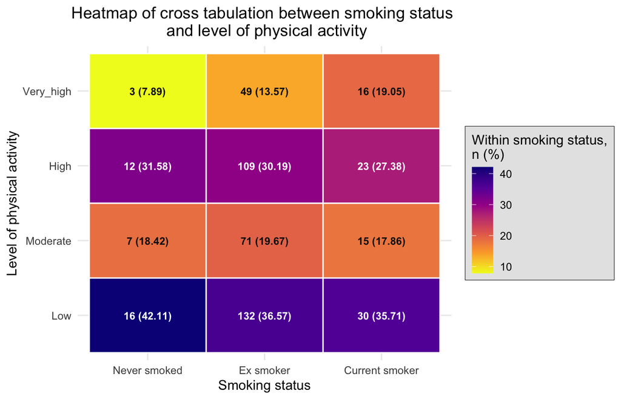

Heatmap of smoking status and level of physical activity

```r
ggplot(data = total_smoker_activity, aes(fsmoker, fphy_activity, fill = pct_within_smoker)) +
    geom_tile(colour = 'white', linewidth = 0.5) +
    geom_text(
        aes(label = freq_row_pct,
            colour = ifelse(pct_within_smoker > 20, 'white', 'black')
        ),
        fontface = 'bold',
        size = 3,
        show.legend = FALSE
    ) +
    scale_fill_viridis_c(
        option = 'C',
        direction = -1,
        name = 'Within smoking status,\nn (%)'
    ) +
    scale_colour_manual(
        values = c('white' = '#FFFFFF', 'black' = '#111111')
    ) +
    labs(
        x = 'Smoking status',
        y = 'Level of physical activity',
        title = 'Heatmap of cross tabulation between smoking status \n and level of physical activity'
    ) +
    theme_minimal() +
    theme(
        plot.title = element_text(hjust = 0.5),
        legend.box.background = element_rect(
            fill = alpha('#e5e5e5', 1), linewidth = 0.2, linetype = "solid", color = "#222222"
        )
    )
```

In those who never smoked and the ex smoker groups, the trends are the same where the majority have a low level of physical activity with 42.11% and 36.57% respectively, followed with high level of physical activity at 31.58% and 30.19%, then moderate levels at 18.42% and 19.67%, and the least populated with very high level of physical activity at 7.89% and 13.57%. However, for current smokers the trend is slightly different where instead of very high level of physical activity being the least frequent, it is swapped with moderate level of physical activity instead.

## Outcome analysis

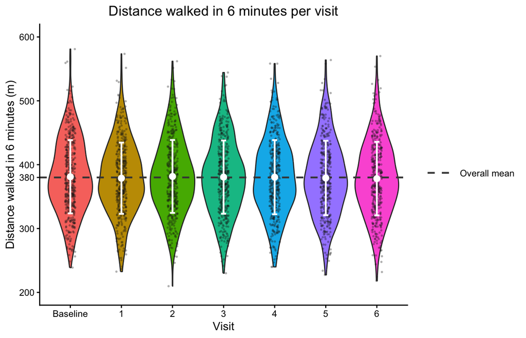

Distance walked in 6 minutes per visit

```r
overall_mean = mean(linked_data$walk6min, na.rm = TRUE)
ggplot(
      data = linked_data[!is.na(linked_data$walk6min),
      c('walk6min', 'fvisit')],
      aes(x = fvisit, y = walk6min, fill = fvisit)
    ) +
    geom_violin() +
    geom_jitter(
      alpha = 0.25, size = 0.4,
      width = 0.1, colour = '#1A1A1A',
      show.legend = FALSE
    ) +
    geom_hline(
      aes(yintercept = overall_mean, linetype ='Overall mean'),
      linewidth = 0.8, colour = '#444444'
    ) +
    stat_summary(# 1 SD
      fun = mean,
      fun.min = function(y) mean(y) - sd(y),
      fun.max = function(y) mean(y) + sd(y),
      geom = 'errorbar', colour = '#FFFFFF',
      width = 0.1, linewidth = 0.8,
    ) +
    stat_summary(# Group mean
      fun = mean, geom = 'point',
      colour = '#FFFFFF', size = 2.5,
      show.legend = FALSE
    ) +
    scale_y_continuous(limits = c(200, 600), breaks = c(seq(200, 600, 100), round(overall_mean))) +
    scale_linetype_manual(
      name = '',
      values = c('Overall mean' = 'dashed')
    ) +
    scale_fill_discrete(guide = 'none') +
    labs(
        x = 'Visit',
        y = 'Distance walked in 6 minutes (m)',
        title = 'Distance walked in 6 minutes per visit',
        fill = 'Visit'
    ) +
    theme_classic() +
    theme(
      plot.title = element_text(hjust = 0.5),
      legend.key.width = unit(1, "cm")
    )
```

Across all the visits including baseline, the distribution of how far the participants are able to walk in 6 minutes across the baseline and all the follow-ups are similar and approximately normal with a few outliers but not notable. The mean and 1 standard deviation spread as noted by the white error bar within each violin is relatively similar. Overall, without accounting for any specific exposures, there is no growth in the distance the participants are able to walk in 6 minutes from the baseline to the follow-ups.

```r
distance_means = aggregate(
    walk6min ~ fvisit, data = linked_data,
    FUN = function(x) round(mean(x), 2)
)
distance_sd = aggregate(
    walk6min ~ fvisit, data = linked_data,
    FUN = function(x) round(sd(x), 2)
)

distance_summary = merge(
    distance_means, distance_sd,
    by = 'fvisit'
)
distance_summary$one_sd_spread = sprintf('%.2f, %.2f',
    distance_summary$walk6min.x - distance_summary$walk6min.y,
    distance_summary$walk6min.x + distance_summary$walk6min.y
)

kable(distance_summary[order(distance_summary$fvisit),],
    align = 'l',
    col.names = c('Visit', 'Average 6 minutes <br>walk distance (m)',
                  'Standard deviation 6 <br>minutes walk distance (m)',
                  'Mean ± 1 SD'),
    row.names = FALSE
)
```

Summary statistics of 6 minute walk distance without specific exposure

| Visit | Average 6 minutes walk distance (m) | Standard deviation 6 minutes walk distance (m) | Mean ± 1 SD |
| --- | --- | --- | --- |
| Baseline | 381.08 | 57.35 | 323.73, 438.43 |
| 1 | 378.79 | 55.77 | 323.02, 434.56 |
| 2 | 381.56 | 57.07 | 324.49, 438.63 |
| 3 | 380.52 | 57.37 | 323.15, 437.89 |
| 4 | 380.39 | 58.12 | 322.27, 438.51 |
| 5 | 379.16 | 58.29 | 320.87, 437.45 |
| 6 | 378.20 | 57.58 | 320.62, 435.78 |

The table above shows how similar the average and the spread of the data is between the baseline and the follow-ups. It also further shows in detail the absence of growth from the baseline to the follow-ups. The highest average occurred on the second follow up but the increase from the baseline is only by 0.48 metres, while the baseline against all the other follow-ups only decreased. The lowest average is on the last follow-up at 378.20 metres, almost 3 metres lower than the baseline.

```r
# Subset dataframe to only include variables of interest and exclude NA values
analysis_df = subset(linked_data,
     !is.na(walk6min) & (
       !is.na(fsmoker) |
       !is.na(fphy_activity)
     ),
     select = c(fsmoker, fphy_activity, fvisit, walk6min)
)
```

### Univariate analysis

```r
smoker_outcome_plot = function(smoking_status) {
    # Filter dataframe
    df = analysis_df[analysis_df$fsmoker == smoking_status & !is.na(analysis_df$fsmoker), ]
    # Fetch the mean within the filtered smoker group
    within_group_mean = round(mean(df$walk6min))

    # Build the graph
    ggplot(
        data = df,
        aes(x = fsmoker, y = walk6min, fill = fvisit)
    ) +
    geom_violin(width = 0.85) +
    geom_hline(
      aes(yintercept = within_group_mean, linetype ='Within group mean'),
      linewidth = 0.8, colour = '#444444'
    ) +
    stat_summary(# Within smoking and visit mean
      fun = mean, geom = 'point',
      colour = '#FFFFFF', size = 1.5,
      show.legend = FALSE, position = position_dodge(width = 0.85)
    ) +
    scale_linetype_manual(
      name = '',
      values = c('Within group mean' = 'dashed')
    ) +
    scale_y_continuous(
        limits = c(200, 600),
        breaks = c(seq(200, 600, 100), within_group_mean)
    ) +
    scale_fill_manual(values = c('#E69F00', '#56B4E9', '#009E73', '#F0E442', '#0072B2', '#D55E00', '#CC79A7')) +
    labs(
        x = 'Smoking status',
        y = 'Distance walked in 6 minutes (m)',
        fill = 'Visit'
    ) +
    theme_classic() +
    theme(
      legend.key.width = unit(1, "cm")
    )
}
```

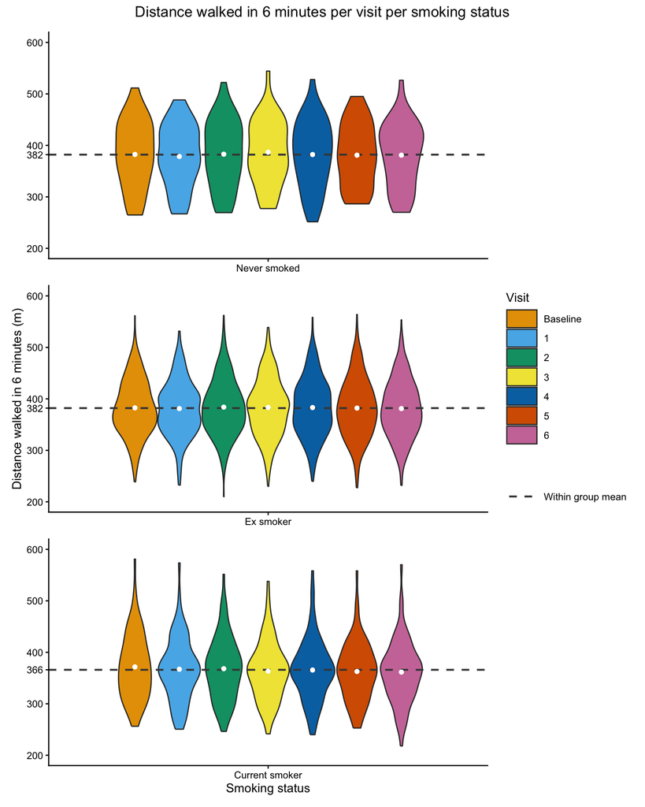

```r
never_smoked = smoker_outcome_plot('Never smoked')
ex_smoker = smoker_outcome_plot('Ex smoker')
current_smoker = smoker_outcome_plot('Current smoker')

never_smoked / ex_smoker / current_smoker +
    plot_layout(
        guides = 'collect',
        axis_titles = 'collect'
    ) +
    plot_annotation(
        title = 'Distance walked in 6 minutes per visit per smoking status',
        theme = theme(plot.title = element_text(hjust = 0.5))
    )
```

Taking into account only the participants’ smoking status, it is clear that current smokers has a far lower 6 minutes walk distance average at each visit as well as the overall average compared to ex smokers and those who never smoked. Those who never smoked and ex smokers have very similar averages across all the visits. However, the shape of the violins for those who never smoked and ex smokers are different. Those who never smoked tend to be wider above the group mean, while ex smokers tend to be wider below the group mean.

```r
activity_outcome_plot = function(activity) {
    # Filter dataframe
    df = analysis_df[analysis_df$fphy_activity == activity & !is.na(analysis_df$fphy_activity), ]
    # Fetch the mean within the filtered activity group
    within_group_mean = round(mean(df$walk6min), 2)

    # Build the graph
    ggplot(
        data = df,
        aes(x = fphy_activity, y = walk6min, fill = fvisit)
    ) +
    geom_violin(width = 0.85) +
    geom_hline(
      aes(yintercept = within_group_mean, linetype ='Within group mean'),
      linewidth = 0.8, colour = '#444444'
    ) +
    stat_summary(# Within activity and visit mean
      fun = mean, geom = 'point',
      colour = '#FFFFFF', size = 1.5,
      show.legend = FALSE, position = position_dodge(width = 0.85)
    ) +
    scale_linetype_manual(
      name = '',
      values = c('Within group mean' = 'dashed')
    ) +
    scale_y_continuous(
        limits = c(200, 600),
        breaks = c(seq(200, 600, 100),
             ifelse(activity == 'Low', NA, within_group_mean) # Remove y tick on low to avoid clashing
        )
    ) +
    scale_fill_manual(values = c('#E69F00', '#56B4E9', '#009E73', '#F0E442', '#0072B2', '#D55E00', '#CC79A7')) +
    labs(
        x = 'Level of physical activity',
        y = 'Distance walked in 6 minutes (m)',
        fill = 'Visit'
    ) +
    theme_classic() +
    theme(
      legend.key.width = unit(1, "cm")
    )
}
```

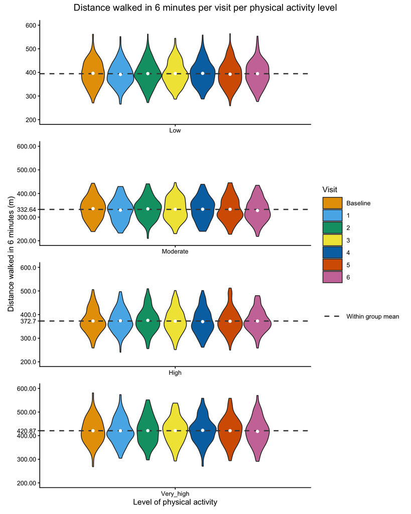

```r
low_phys = activity_outcome_plot('Low')
moderate_phys = activity_outcome_plot('Moderate')
high_phys = activity_outcome_plot('High')
very_high_phys = activity_outcome_plot('Very_high')

low_phys / moderate_phys / high_phys / very_high_phys +
    plot_layout(
        guides = 'collect',
        axis_titles = 'collect'
    ) +
    plot_annotation(
        title = 'Distance walked in 6 minutes per visit per physical activity level',
        theme = theme(plot.title = element_text(hjust = 0.5))
    )
```

### Multivariate analysis

```r
multivariate_df_mean = aggregate(
    walk6min ~ fvisit + fsmoker + fphy_activity,
    data = analysis_df[!is.na(analysis_df$fsmoker) & !is.na(analysis_df$fphy_activity), ],
    FUN = mean,
    na.rm = TRUE
)
multivariate_df_sd = aggregate(
    walk6min ~ fvisit + fsmoker + fphy_activity,
    data = analysis_df[!is.na(analysis_df$fsmoker) & !is.na(analysis_df$fphy_activity), ],
    FUN = sd,
    na.rm = TRUE
)
multivariate_df_len = aggregate(
    walk6min ~ fvisit + fsmoker + fphy_activity,
    data = analysis_df[!is.na(analysis_df$fsmoker) & !is.na(analysis_df$fphy_activity), ],
    FUN = length
)
multivariate_df = merge(
    merge(
        multivariate_df_mean, multivariate_df_sd,
        by = c('fvisit', 'fsmoker', 'fphy_activity')
    ), multivariate_df_len,
    by = c('fvisit', 'fsmoker', 'fphy_activity')
)
colnames(multivariate_df)[c(4, 5, 6)] = c('mean', 'sd', 'n')
multivariate_df$lower_ci = multivariate_df$mean - 1.96 * (multivariate_df$sd / sqrt(multivariate_df$n))
multivariate_df$upper_ci = multivariate_df$mean + 1.96 * (multivariate_df$sd / sqrt(multivariate_df$n))
# multivariate_df[order(multivariate_df$fsmoker, multivariate_df$fphy_activity, multivariate_df$fvisit), ]
```

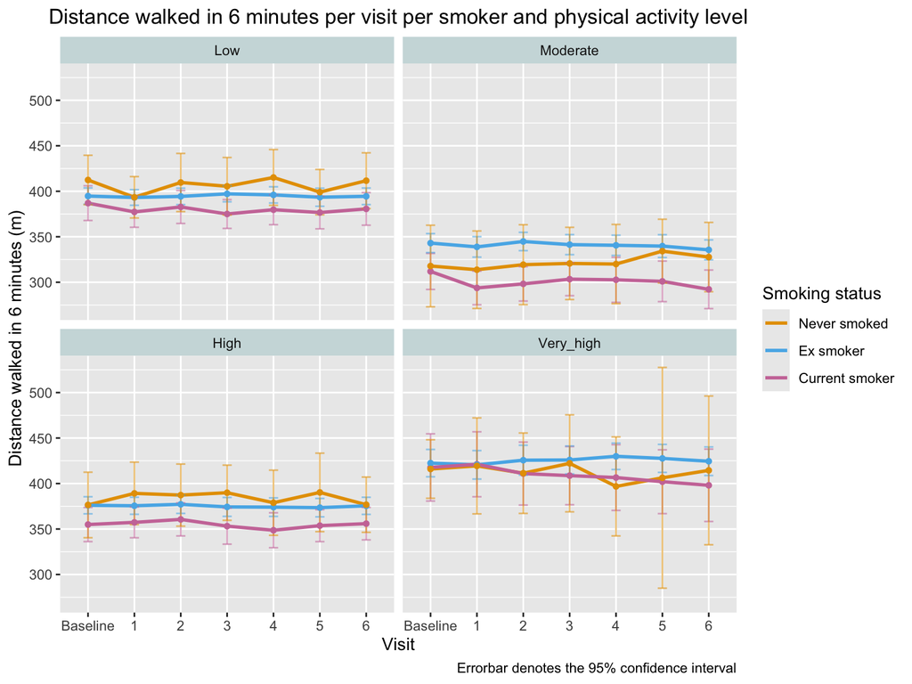

6 minutes walk distance per visit for every smoking status and physical activity level

```r
ggplot(
    data = multivariate_df,
    aes(x = fvisit, y = mean, colour = fsmoker, group = fsmoker)
) +
    geom_line(linewidth = 1) +
    geom_errorbar(aes(
            ymin = lower_ci,
            ymax = upper_ci,
            width = 0.2, linetype = 'solid',
            alpha = 0.8
        ), show.legend = FALSE
    ) +
    geom_point(size = 1.3, show.legend = FALSE) +
    facet_wrap(~ fphy_activity) +
    scale_colour_manual(values = c("#E69F00", "#56B4E9", "#CC79A7")) +
    labs(
        x = 'Visit',
        y = 'Distance walked in 6 minutes (m)',
        title = 'Distance walked in 6 minutes per visit per smoker and physical activity level',
        colour = 'Smoking status',
        caption = 'Errorbar denotes the 95% confidence interval'
    ) +
    theme(
        plot.title = element_text(hjust = 0.5),
        strip.background = element_rect(fill = "#CDDCDD")
    )
```

Participants with **low physical activity level**, particularly those who never smoked generally performed better than ex smokers and current smokers hovering around 400 metres 6 minutes walk distance and lower for the other smoker groups. Those who never smoked also have a very fluctuative trend, while ex smoker and current smoker have a very stagnant trend. In the **moderate physical activity** group, there is a clear difference in performance between the three smoking groups. The ex smoker group had the highest 6 minutes walk distance across all the visits, followed with the never smoked group, and the current smoker group with average difference being 46 metres at the highest and 32 at the lowest. For the **high physical activity** participants, it shares a similar pattern with the low physical activity group but instead the never smoked groups’ overall 6 minutes walk distance is around 380 metres and lower for the other smoker groups. The **very high physical activity** group has a different pattern than the other groups, where the baseline and first follow-up is nearly identical for the three smoking groups and starting from the second follow-up, it starts to diverge. The ex smoker group starts to rise slighly but ends at around the same as the baseline at the last follow-up, the never smoked group fluctuates rapidly but also ends around the same point at the final follow-up. However, the current smoker group shows a clear downturn from the first follow-up to the last follow-up.

# Summary and limitations

## Limitations

A few limitations exist in this study with the most notable being the lack of statistical tests done which makes it hard to suggest any significance in the possible differences across the smoking and physical activity level groups. Furthermore, the study only has participants aged 60-75 years old which severely limits the target population of the findings. The majority of the participants with nearly 75% are ex smokers, while the rest is either those who never smoked at 8% or current smokers at 17.4%. These differences in the sample size may blur the conclusion for the less frequent groups, for example shown in the never smoked with very high physical activity level where the confidence interval is very wide due to lack of sample size. The lack of a regression model also makes it hard to quantify the magnitude of smoking status and physical activity level against 6 minutes walk distance.

## GenAI Declaration

Generative AI (Claude) was used in completing this assessment to quickly search up how to enhance the plot builder I have in both univariate analyses.

To solve the issue where I wanted to display the mean as a point within each smoking status and within each visit, I passed the prompt:

```
stat_summary(
fun = mean, geom = 'point',
colour = '#FFFFFF', size = 2.5,
show.legend = FALSE
)

on a violin plot where x and fill are different categorical variables, how do i create a point mean within each permutation?
```

which returned the suggestion

```
The issue is that stat_summary doesn't know about the dodge by default. The violins are dodged by fill, but your points are being drawn at the x position only, so they're stacked in the middle. You need to dodge the points the same way, and make sure the grouping is by fill as well.

ggplot(df, aes(x = cat_x, y = value, fill = cat_fill)) +
  geom_violin(position = position_dodge(width = 0.9)) +
  stat_summary(
    fun = mean, geom = "point",
    aes(group = cat_fill),
    position = position_dodge(width = 0.9),
    colour = "#FFFFFF", size = 2.5,
    show.legend = FALSE
  )
```